#Upload dataset

# Specify the type of variables

# Summary of the dataset

The function describe gives the sample size, missing, unique, mean, 5,10,25,50,75,90,95th percentiles, lowest, highest value for all columns in the dataset

```
## data
##
##  21  Variables      15045  Observations
## ---------------------------------------------------------------------------
## leverage
##        n  missing distinct     Info     Mean      Gmd      .05      .10
##    15045        0     4101        1    8.895    14.72   -3.798    0.330
##      .25      .50      .75      .90      .95
##    1.250    3.730    9.850   23.456   38.762
##
## lowest : -67.15 -65.53 -65.29 -65.13 -64.43, highest: 200.70 201.25 202.19 206.55 207.09
## ---------------------------------------------------------------------------
## fin_leverage
##        n  missing distinct     Info     Mean      Gmd      .05      .10
##    15045        0     1597    0.932    1.258    2.399   -0.010    0.000
##      .25      .50      .75      .90      .95
##    0.000    0.060    1.170    3.826    6.898
##
## lowest : -9.59 -9.58 -9.57 -9.42 -9.33, highest: 32.33 32.46 32.67 32.79 33.38
## ---------------------------------------------------------------------------
## ta_tl
##        n  missing distinct     Info     Mean      Gmd      .05      .10
##    15045        0      575        1    1.462   0.6637    0.880    1.010
##      .25      .50      .75      .90      .95
##    1.070    1.200    1.540    2.226    2.940
##
## lowest : 0.10 0.14 0.16 0.17 0.19, highest: 8.11 8.13 8.18 8.24 8.27
## ---------------------------------------------------------------------------
## current_ratio
##        n  missing distinct     Info     Mean      Gmd      .05      .10
##    15045        0      737        1    1.541    1.035    0.440    0.650
##      .25      .50      .75      .90      .95
##    0.970    1.220    1.720    2.670    3.618
##
## lowest :  0.00  0.01  0.02  0.03  0.04, highest: 14.10 14.66 15.27 15.33 15.89
## ---------------------------------------------------------------------------
## quick_ratio
##        n  missing distinct     Info     Mean      Gmd      .05      .10
##    15045        0      629        1    1.189   0.9143     0.21     0.33
##      .25      .50      .75      .90      .95
```

[output cut: 119 more lines]

```
##        n  missing distinct     Info     Mean      Gmd
##    15045        0        8    0.923    4.215    1.709
##
## Value          0     1     2     3     4     5     6     7
## Frequency    271    29  3797   103  2086  5481  3217    61
## Proportion 0.018 0.002 0.252 0.007 0.139 0.364 0.214 0.004
## ---------------------------------------------------------------------------
## comp_size
##        n  missing distinct     Info     Mean      Gmd
##    15045        0        2    0.224    1.081   0.1494
##
## Value          1     2
## Frequency  13822  1223
## Proportion 0.919 0.081
## ---------------------------------------------------------------------------
```

# We notice DSO DPO problem:

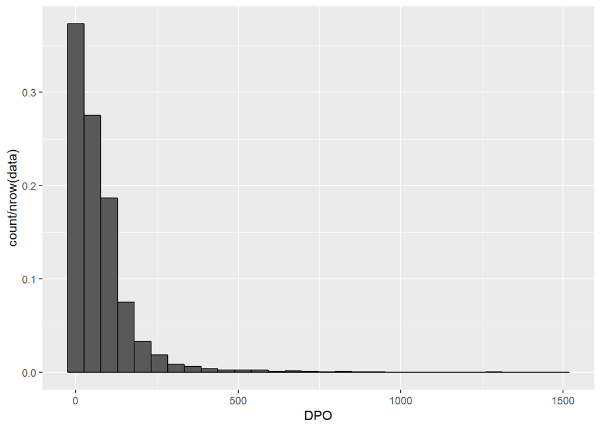

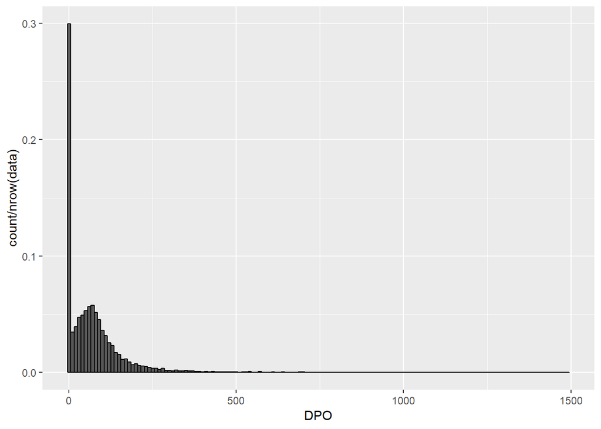

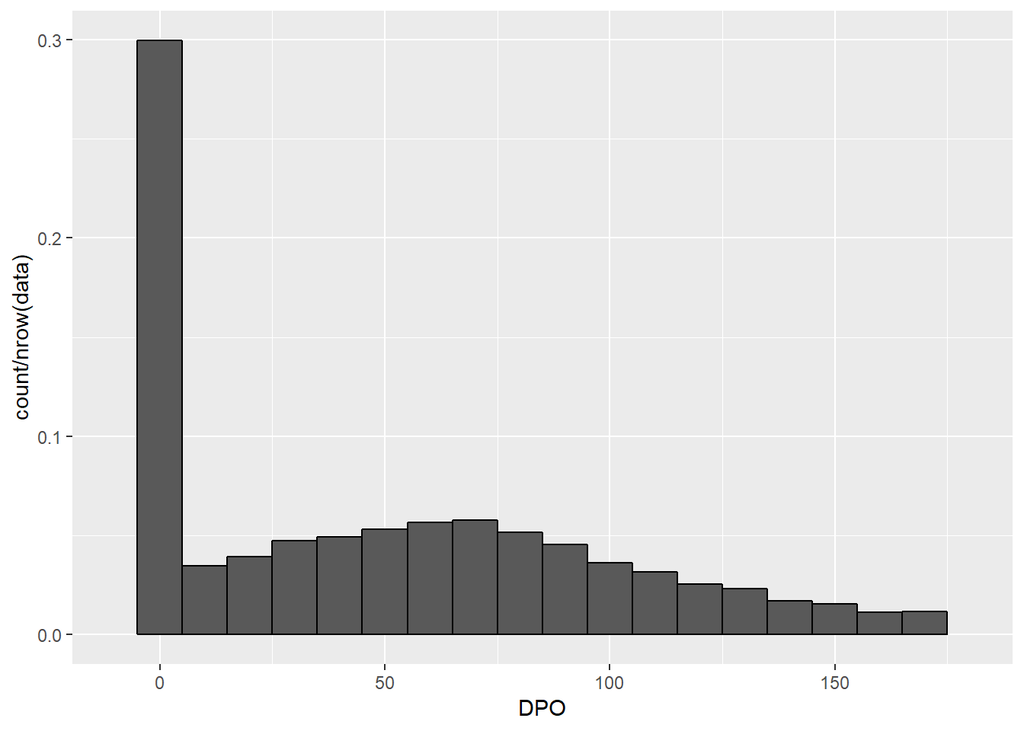

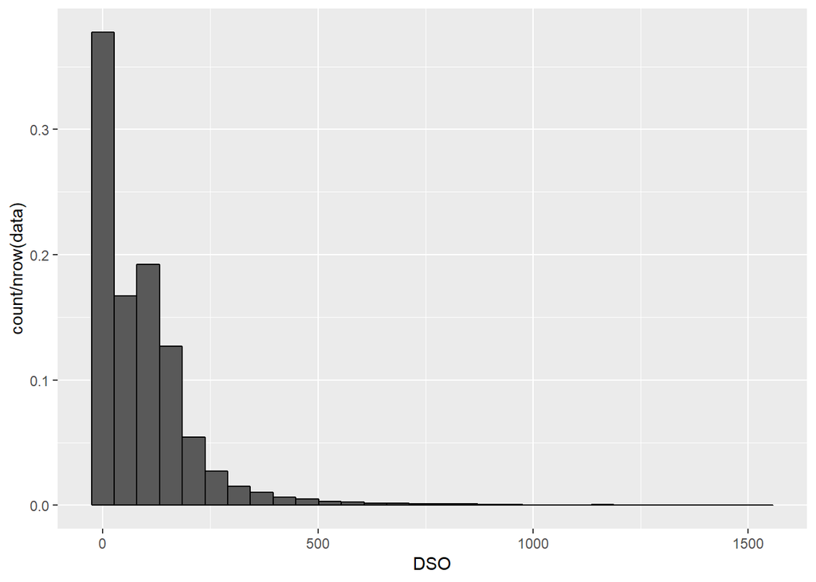

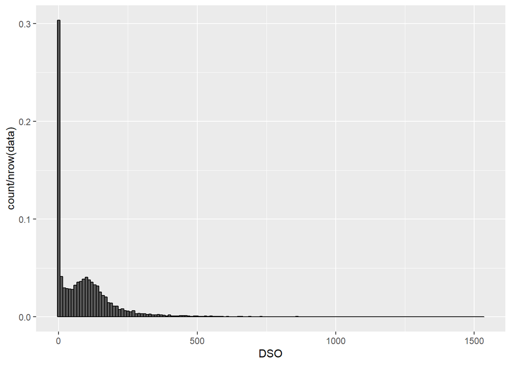

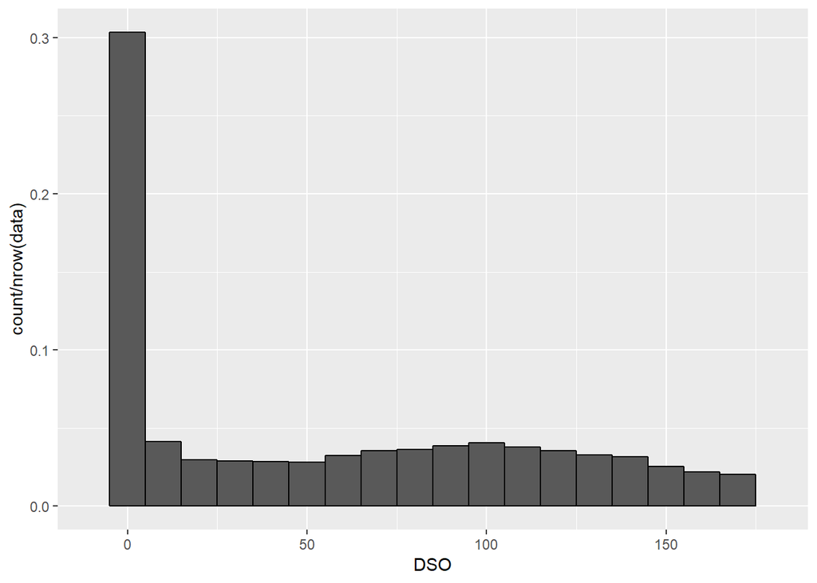

# Short format FS

issue of short form FS-> small Cos. Let’s see what happens if we “remove” companies that file short form financials (i.e. turnover > 8.8 M)

```
## [1] 1223   21
```

```
## [1] 13822    21
```

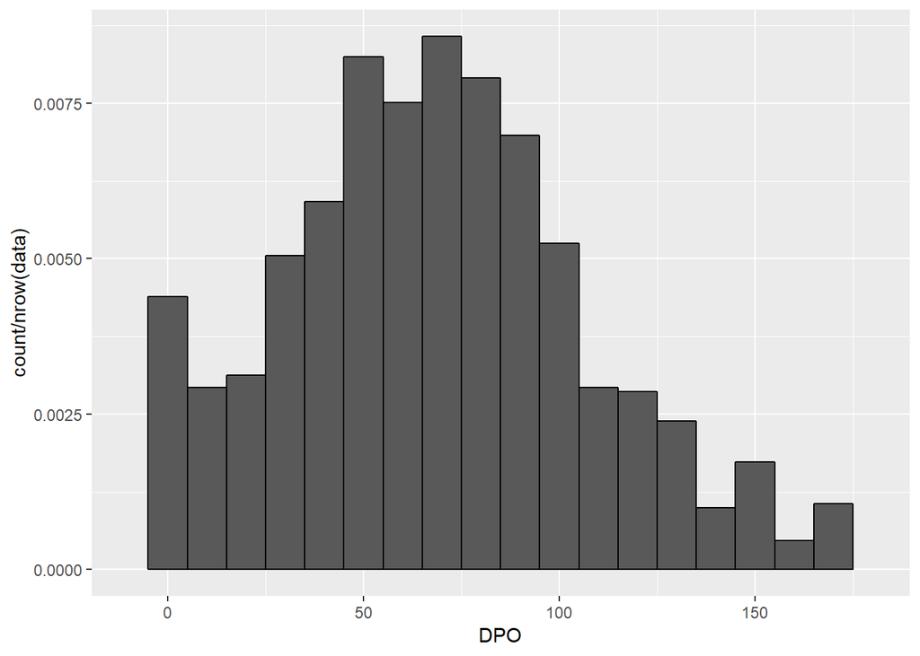

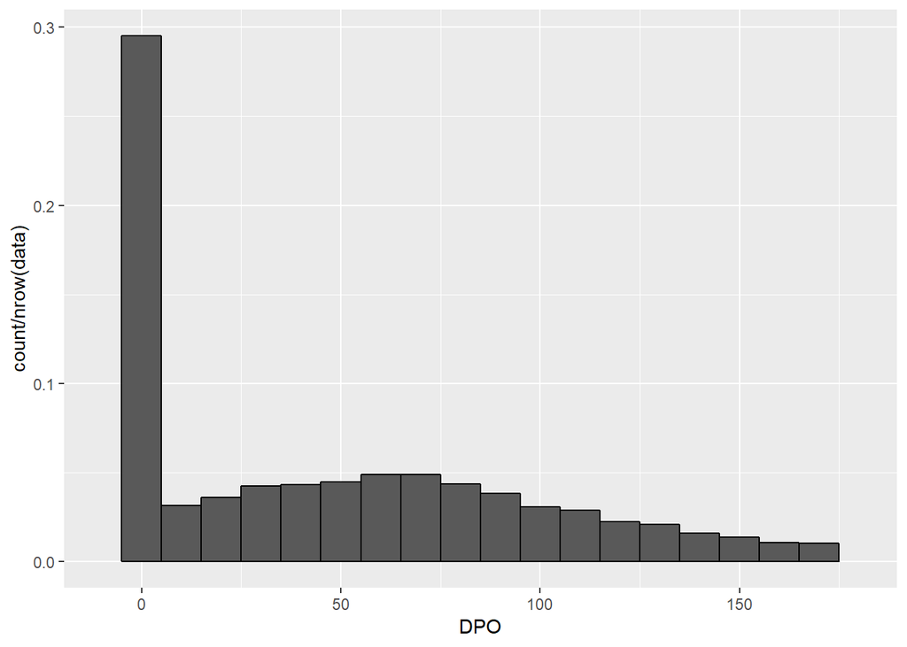

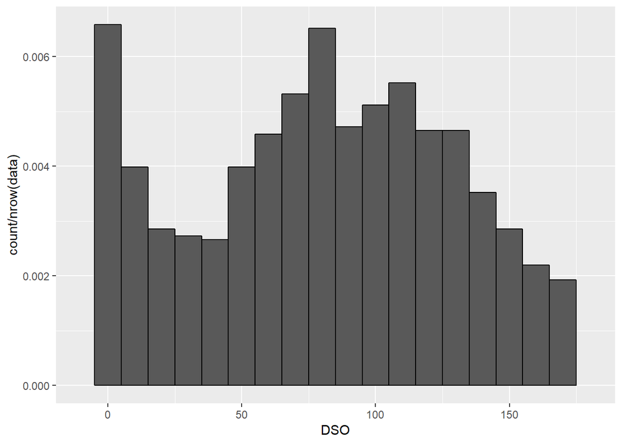

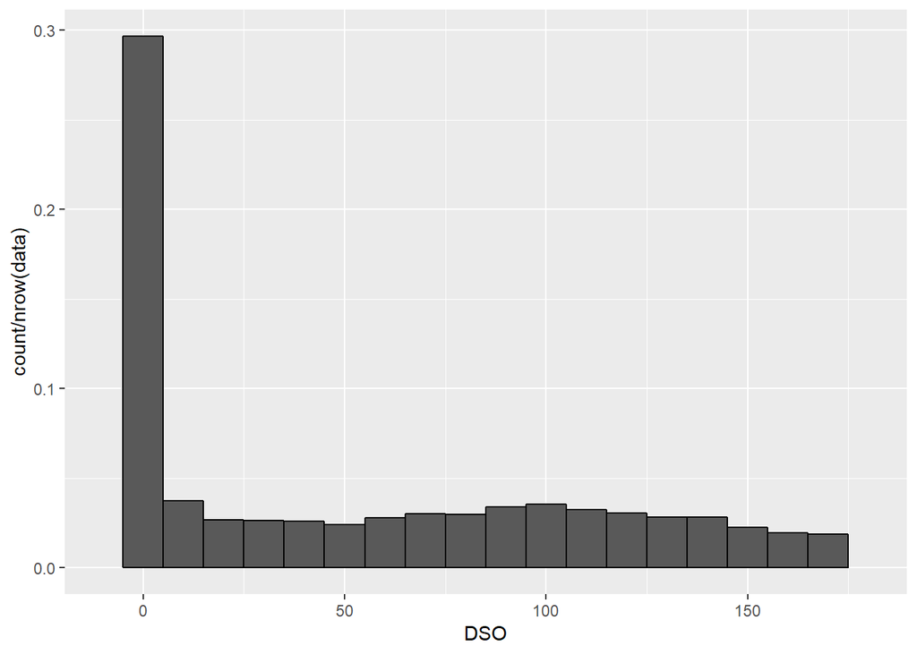

#Size dependency of ratios Let us see if there is different behaviour of other rations depending on size

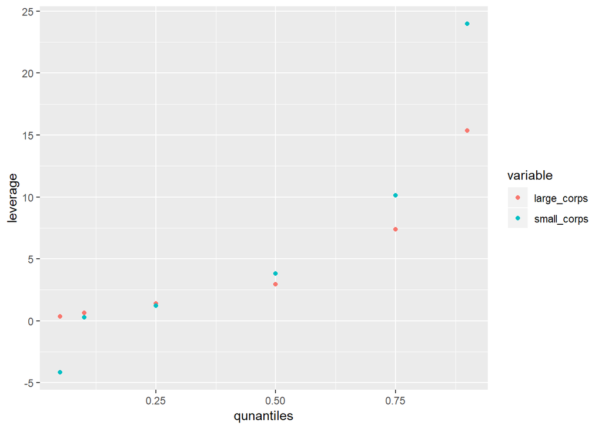

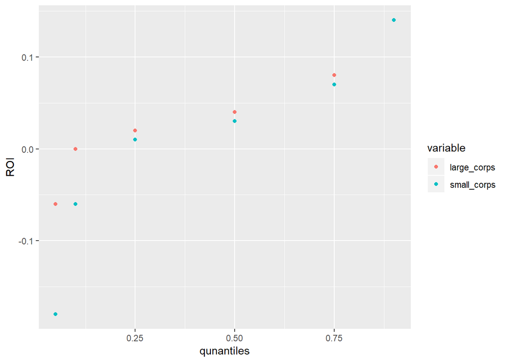

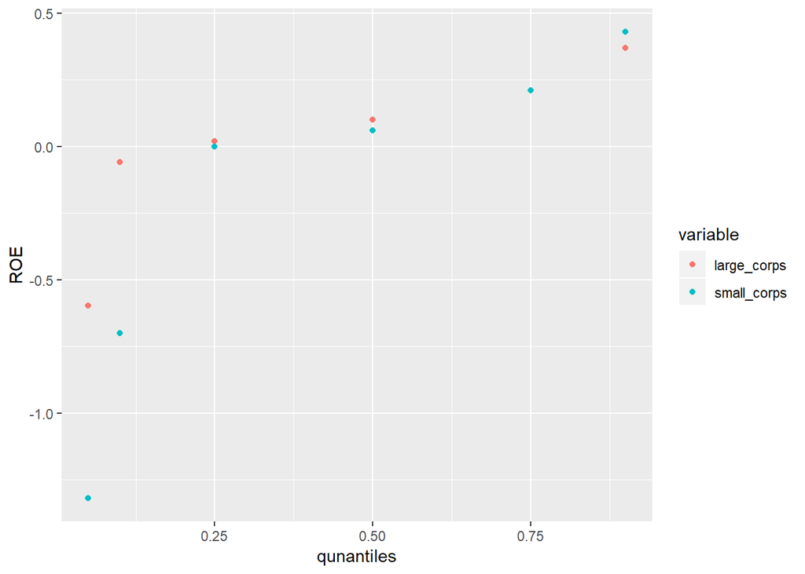

# Boxplot Another interesting tool to carry on data analysis are Box Plots. Once again knowledge of the facts is mandatory to carry on a reliable analaysis

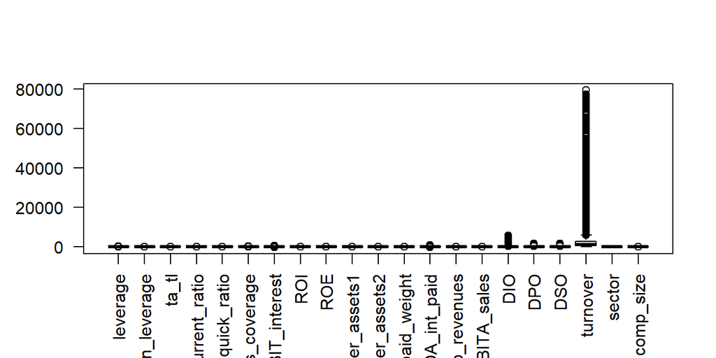

#We’ve to keep in mind what we’re looking at: ROI has a different range than leverage and both are far different than turnover… You cannot compare everything toghether.

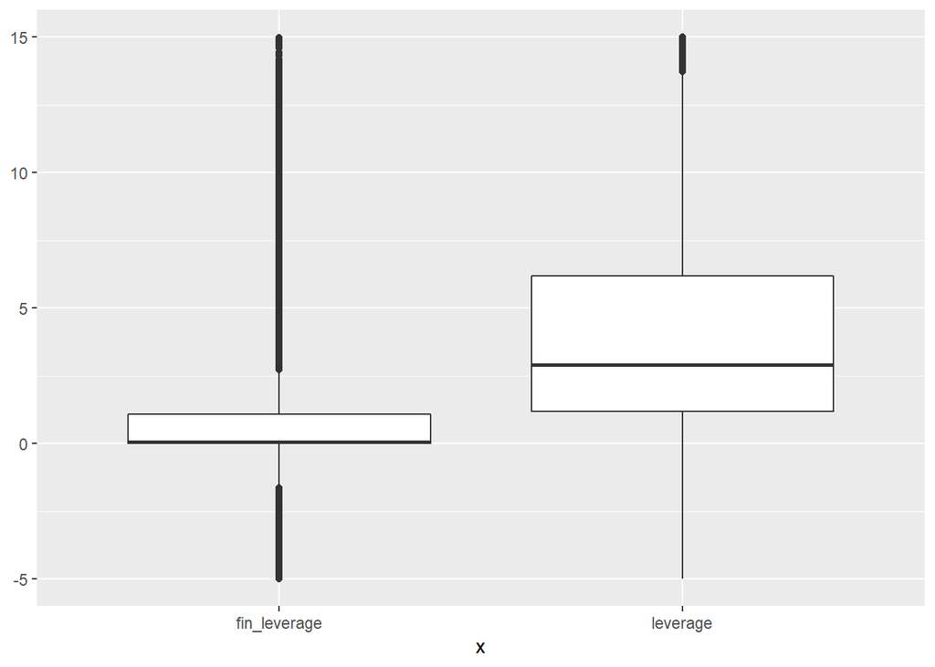

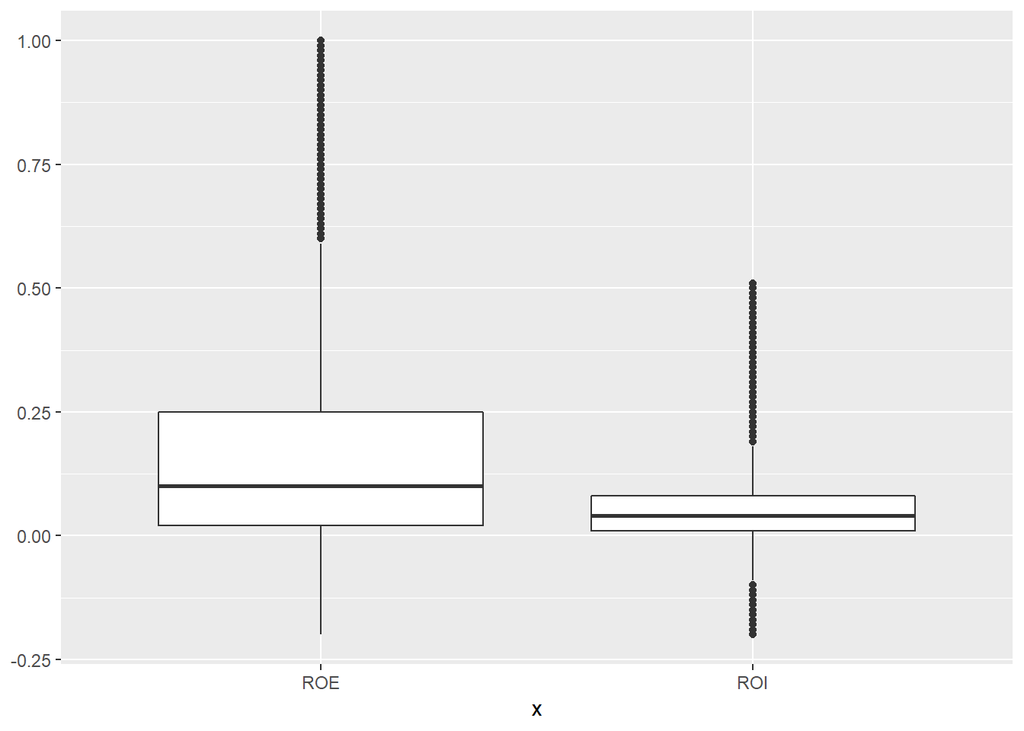

#Box plot come handy to study other dependencies, such as ratios vs sector, or size:

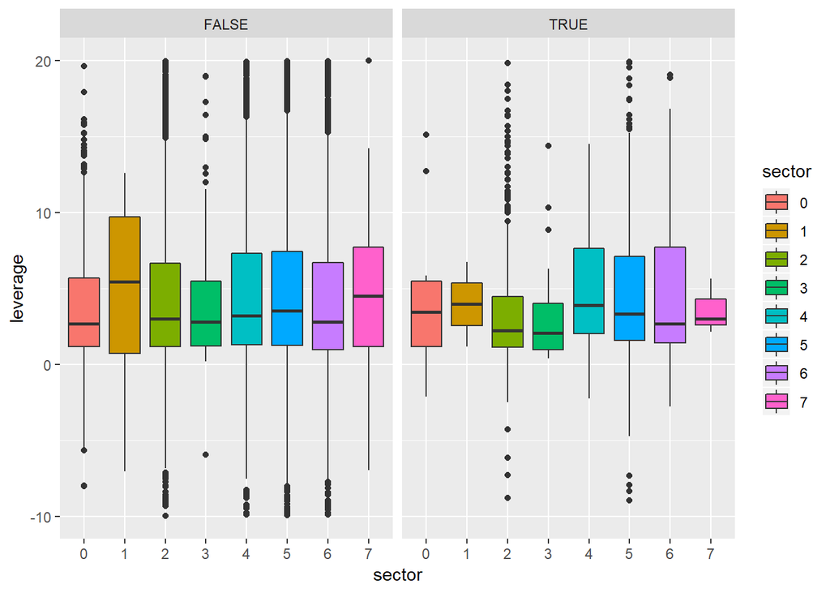

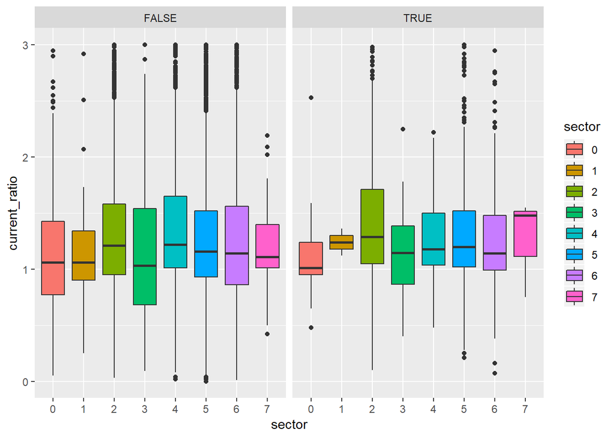

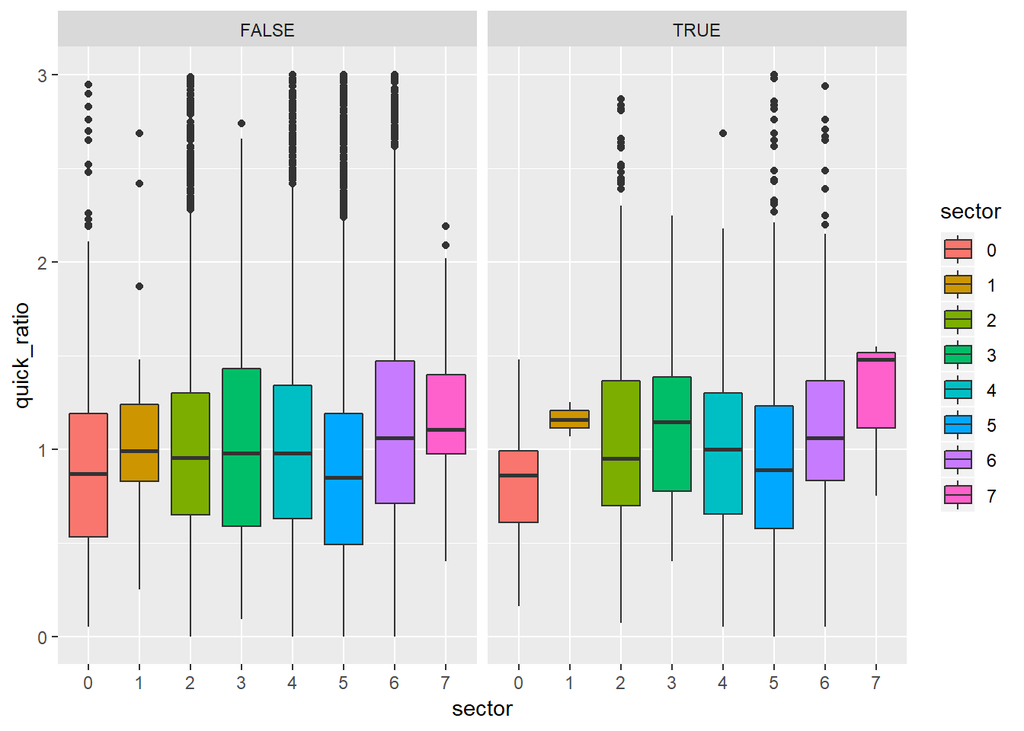

# Analysis Active vs Defaulted

In the end, the key point when developing a scoring model, is to identify ratio’s discriminating capacity…

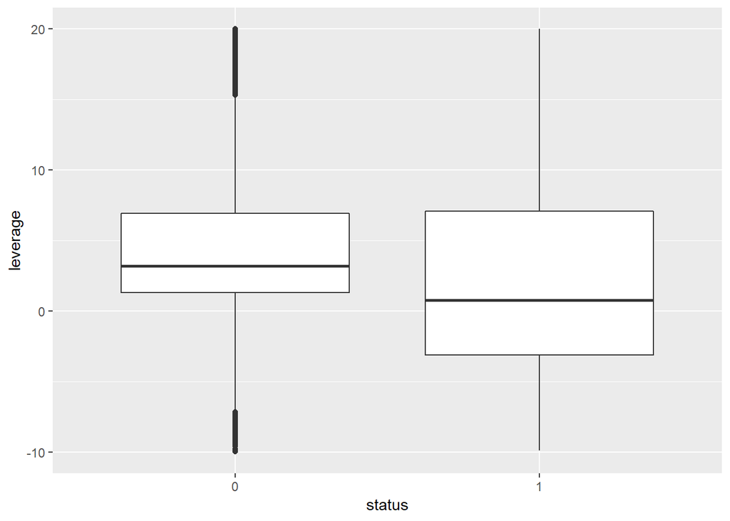

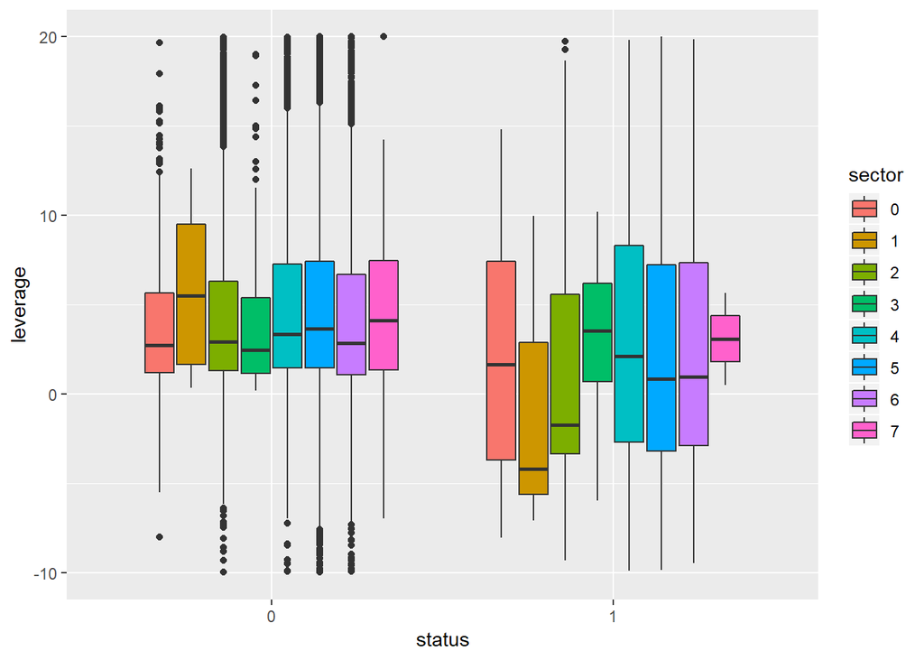

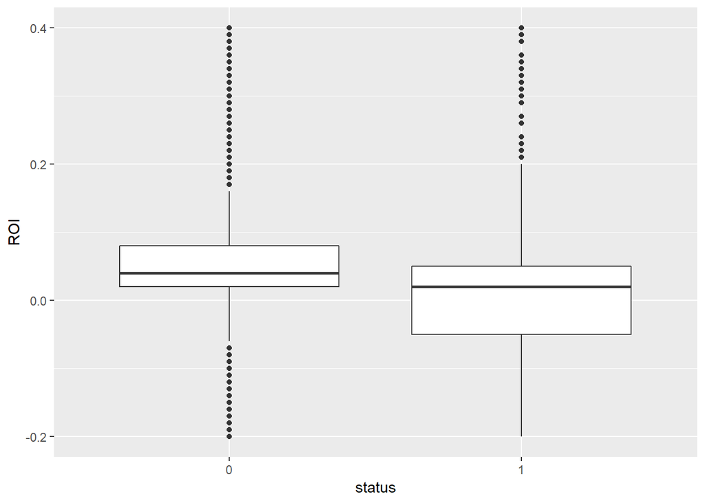

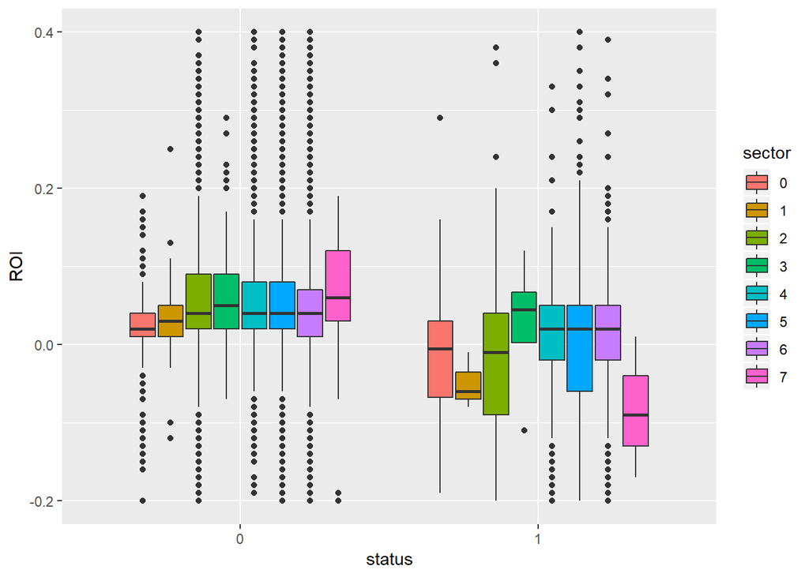

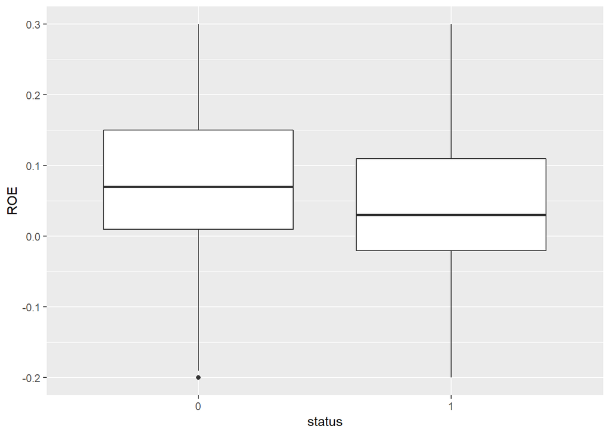

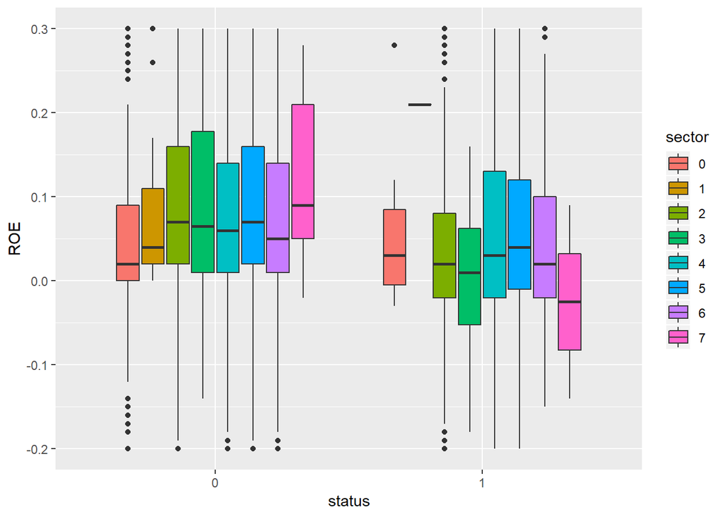

# NOTICE

leverage of defaulted companies is lower than active ones? Weird… let’s see what appens:

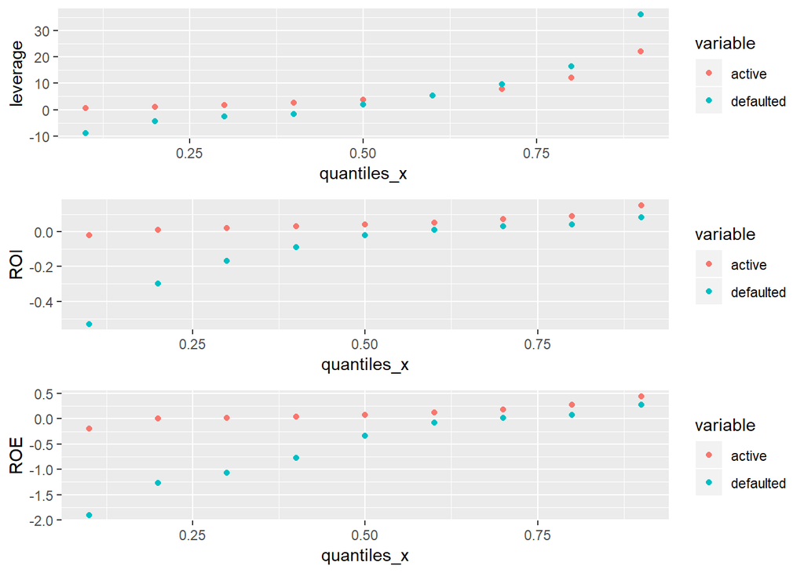

# Correlation analysis

Once identified companies with the highest discriminating capacity, we’ve to check for correlation: we may have three very “powerful” variables, but if they’re totally corrleated, they do not bring value to our model.

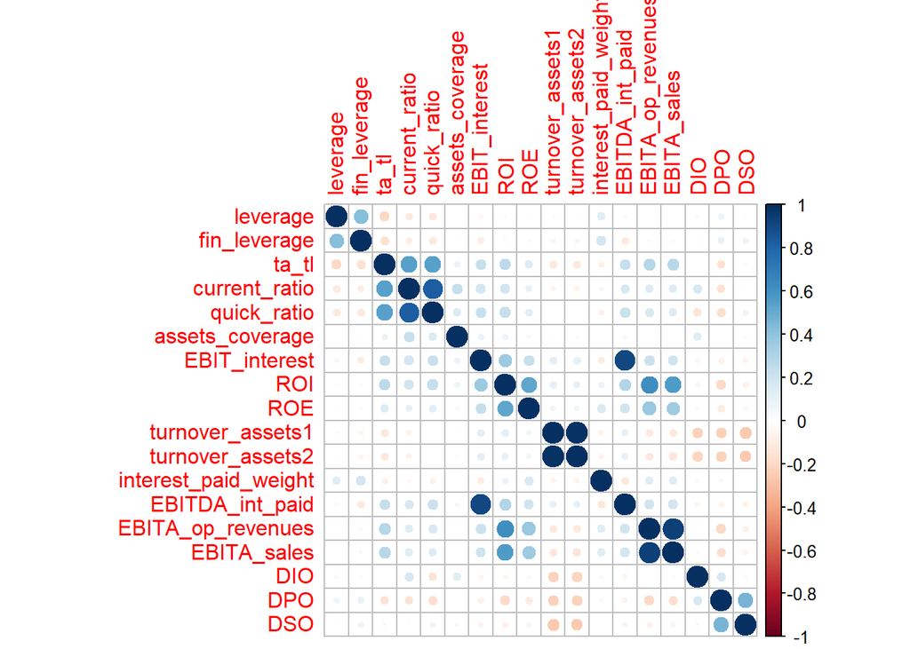

#sector subgroups